# Risk Factor Analysis

## Outcome Variable

**Outcome Variable:** wasted

## Predictor Variables

**Intervention Variable:** nchldlt5

**Adjustment Set:**

unadjusted

## Stratifying Variables

The analysis was stratified on these variable(s):

- agecat
- studyid
- country

## Data Summary

| agecat | studyid | country | nchldlt5 | wasted | n_cell | n |
| --- | --- | --- | --- | --- | --- | --- |
| Birth | IRC | INDIA | 1 | 0 | 50 | 343 |
| Birth | IRC | INDIA | 1 | 1 | 22 | 343 |
| Birth | IRC | INDIA | 2+ | 0 | 201 | 343 |
| Birth | IRC | INDIA | 2+ | 1 | 70 | 343 |
| Birth | NIH-Crypto | BANGLADESH | 1 | 0 | 385 | 707 |
| Birth | NIH-Crypto | BANGLADESH | 1 | 1 | 119 | 707 |
| Birth | NIH-Crypto | BANGLADESH | 2+ | 0 | 150 | 707 |
| Birth | NIH-Crypto | BANGLADESH | 2+ | 1 | 53 | 707 |
| Birth | PROVIDE | BANGLADESH | 1 | 0 | 295 | 532 |
| Birth | PROVIDE | BANGLADESH | 1 | 1 | 90 | 532 |
| Birth | PROVIDE | BANGLADESH | 2+ | 0 | 120 | 532 |
| Birth | PROVIDE | BANGLADESH | 2+ | 1 | 27 | 532 |
| 6 months | IRC | INDIA | 1 | 0 | 77 | 408 |
| 6 months | IRC | INDIA | 1 | 1 | 11 | 408 |
| 6 months | IRC | INDIA | 2+ | 0 | 277 | 408 |
| 6 months | IRC | INDIA | 2+ | 1 | 43 | 408 |
| 6 months | LCNI-5 | MALAWI | 1 | 0 | 384 | 811 |
| 6 months | LCNI-5 | MALAWI | 1 | 1 | 6 | 811 |
| 6 months | LCNI-5 | MALAWI | 2+ | 0 | 413 | 811 |
| 6 months | LCNI-5 | MALAWI | 2+ | 1 | 8 | 811 |
| 6 months | NIH-Crypto | BANGLADESH | 1 | 0 | 494 | 715 |
| 6 months | NIH-Crypto | BANGLADESH | 1 | 1 | 13 | 715 |
| 6 months | NIH-Crypto | BANGLADESH | 2+ | 0 | 200 | 715 |
| 6 months | NIH-Crypto | BANGLADESH | 2+ | 1 | 8 | 715 |
| 6 months | PROVIDE | BANGLADESH | 1 | 0 | 421 | 603 |
| 6 months | PROVIDE | BANGLADESH | 1 | 1 | 17 | 603 |
| 6 months | PROVIDE | BANGLADESH | 2+ | 0 | 157 | 603 |
| 6 months | PROVIDE | BANGLADESH | 2+ | 1 | 8 | 603 |
| 6 months | TanzaniaChild2 | TANZANIA, UNITED REPUBLIC OF | 1 | 0 | 1335 | 2019 |
| 6 months | TanzaniaChild2 | TANZANIA, UNITED REPUBLIC OF | 1 | 1 | 55 | 2019 |
| 6 months | TanzaniaChild2 | TANZANIA, UNITED REPUBLIC OF | 2+ | 0 | 597 | 2019 |
| 6 months | TanzaniaChild2 | TANZANIA, UNITED REPUBLIC OF | 2+ | 1 | 32 | 2019 |
| 24 months | IRC | INDIA | 1 | 0 | 78 | 409 |
| 24 months | IRC | INDIA | 1 | 1 | 11 | 409 |
| 24 months | IRC | INDIA | 2+ | 0 | 300 | 409 |
| 24 months | IRC | INDIA | 2+ | 1 | 20 | 409 |
| 24 months | LCNI-5 | MALAWI | 1 | 0 | 271 | 555 |
| 24 months | LCNI-5 | MALAWI | 1 | 1 | 6 | 555 |
| 24 months | LCNI-5 | MALAWI | 2+ | 0 | 274 | 555 |
| 24 months | LCNI-5 | MALAWI | 2+ | 1 | 4 | 555 |
| 24 months | NIH-Crypto | BANGLADESH | 1 | 0 | 328 | 514 |
| 24 months | NIH-Crypto | BANGLADESH | 1 | 1 | 29 | 514 |
| 24 months | NIH-Crypto | BANGLADESH | 2+ | 0 | 141 | 514 |
| 24 months | NIH-Crypto | BANGLADESH | 2+ | 1 | 16 | 514 |
| 24 months | PROVIDE | BANGLADESH | 1 | 0 | 379 | 579 |
| 24 months | PROVIDE | BANGLADESH | 1 | 1 | 45 | 579 |
| 24 months | PROVIDE | BANGLADESH | 2+ | 0 | 138 | 579 |
| 24 months | PROVIDE | BANGLADESH | 2+ | 1 | 17 | 579 |
| 24 months | TanzaniaChild2 | TANZANIA, UNITED REPUBLIC OF | 1 | 0 | 5 | 6 |
| 24 months | TanzaniaChild2 | TANZANIA, UNITED REPUBLIC OF | 1 | 1 | 0 | 6 |
| 24 months | TanzaniaChild2 | TANZANIA, UNITED REPUBLIC OF | 2+ | 0 | 1 | 6 |
| 24 months | TanzaniaChild2 | TANZANIA, UNITED REPUBLIC OF | 2+ | 1 | 0 | 6 |

The following strata were considered:

- agecat: 24 months, studyid: IRC, country: INDIA
- agecat: 24 months, studyid: LCNI-5, country: MALAWI
- agecat: 24 months, studyid: NIH-Crypto, country: BANGLADESH
- agecat: 24 months, studyid: PROVIDE, country: BANGLADESH
- agecat: 24 months, studyid: TanzaniaChild2, country: TANZANIA, UNITED REPUBLIC OF
- agecat: 6 months, studyid: IRC, country: INDIA
- agecat: 6 months, studyid: LCNI-5, country: MALAWI
- agecat: 6 months, studyid: NIH-Crypto, country: BANGLADESH
- agecat: 6 months, studyid: PROVIDE, country: BANGLADESH
- agecat: 6 months, studyid: TanzaniaChild2, country: TANZANIA, UNITED REPUBLIC OF
- agecat: Birth, studyid: IRC, country: INDIA
- agecat: Birth, studyid: NIH-Crypto, country: BANGLADESH
- agecat: Birth, studyid: PROVIDE, country: BANGLADESH

### Dropped Strata

Some strata were dropped due to rare outcomes:

- agecat: 24 months, studyid: LCNI-5, country: MALAWI
- agecat: 24 months, studyid: TanzaniaChild2, country: TANZANIA, UNITED REPUBLIC OF

## Methods Detail

We’re interested in the causal parameters $E[Y_a]$ for all values of $a \in \mathcal{A}$. These parameters represent the mean outcome if, possibly contrary to fact, we intervened to set all units to have $A=a$. Under the randomization and positivity assumptions, these are identified by the statistical parameters $\psi_a=E_W[E_{Y|A,W}(Y|A=a,W)]$. In addition, we’re interested in the mean of $Y$, $E[Y]$ under no intervention (the observed mean). We will estimate these parameters by using SuperLearner to fit the relevant likelihood factors – $E_{Y|A,W}(Y|A=a,W)$ and $p(A=a|W)$, and then updating our likelihood fit using a joint TMLE.

For unadjusted analyses ($W=\{\}$), initial likelihoods were estimated using Lrnr_glm to estimate the simple $E(Y|A)$ and Lrnr_mean to estimate $p(A)$. For adjusted analyses, a small library containing Lrnr_glmnet, Lrnr_xgboost, and Lrnr_mean was used.

Having estimated these parameters, we will then use the delta method to estimate relative risks and attributable risks relative to a prespecified baseline level of $A$.

# Results Detail

## Results Plots

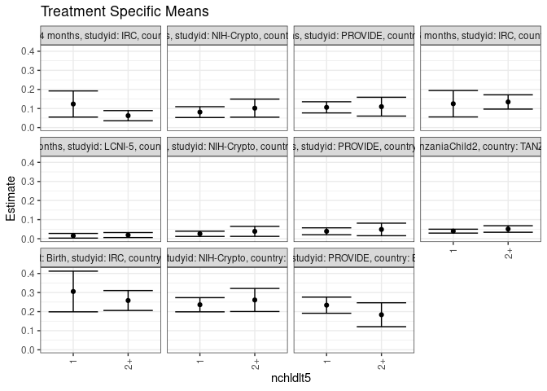

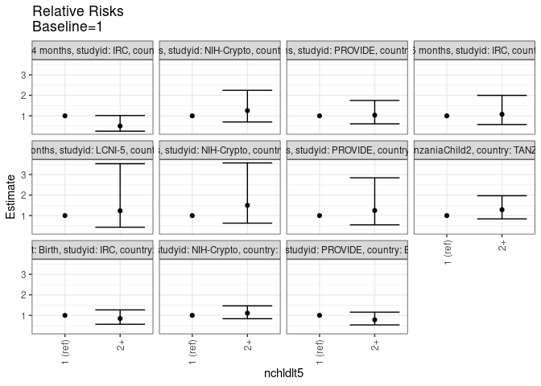

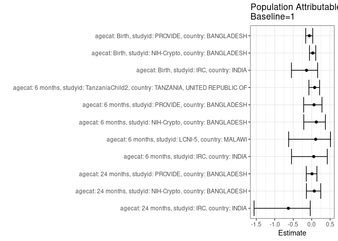

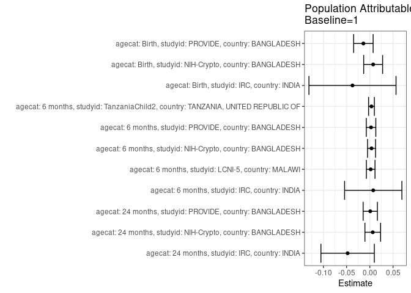

## Results Table

### Parameter: TSM

| agecat | studyid | country | intervention_level | baseline_level | estimate | ci_lower | ci_upper |
| --- | --- | --- | --- | --- | --- | --- | --- |
| Birth | IRC | INDIA | 1 | NA | 0.3055556 | 0.1989991 | 0.4121120 |
| Birth | IRC | INDIA | 2+ | NA | 0.2583026 | 0.2061140 | 0.3104911 |
| Birth | NIH-Crypto | BANGLADESH | 1 | NA | 0.2361111 | 0.1990077 | 0.2732145 |
| Birth | NIH-Crypto | BANGLADESH | 2+ | NA | 0.2610837 | 0.2006200 | 0.3215475 |
| Birth | PROVIDE | BANGLADESH | 1 | NA | 0.2337662 | 0.1914509 | 0.2760816 |
| Birth | PROVIDE | BANGLADESH | 2+ | NA | 0.1836735 | 0.1210188 | 0.2463281 |
| 6 months | IRC | INDIA | 1 | NA | 0.1250000 | 0.0558171 | 0.1941829 |
| 6 months | IRC | INDIA | 2+ | NA | 0.1343750 | 0.0969613 | 0.1717887 |
| 6 months | LCNI-5 | MALAWI | 1 | NA | 0.0153846 | 0.0031621 | 0.0276071 |
| 6 months | LCNI-5 | MALAWI | 2+ | NA | 0.0190024 | 0.0059523 | 0.0320524 |
| 6 months | NIH-Crypto | BANGLADESH | 1 | NA | 0.0256410 | 0.0118729 | 0.0394092 |
| 6 months | NIH-Crypto | BANGLADESH | 2+ | NA | 0.0384615 | 0.0123088 | 0.0646143 |
| 6 months | PROVIDE | BANGLADESH | 1 | NA | 0.0388128 | 0.0207093 | 0.0569163 |
| 6 months | PROVIDE | BANGLADESH | 2+ | NA | 0.0484848 | 0.0156846 | 0.0812851 |
| 6 months | TanzaniaChild2 | TANZANIA, UNITED REPUBLIC OF | 1 | NA | 0.0395683 | 0.0293176 | 0.0498191 |
| 6 months | TanzaniaChild2 | TANZANIA, UNITED REPUBLIC OF | 2+ | NA | 0.0508744 | 0.0336976 | 0.0680512 |
| 24 months | IRC | INDIA | 1 | NA | 0.1235955 | 0.0551353 | 0.1920557 |
| 24 months | IRC | INDIA | 2+ | NA | 0.0625000 | 0.0359460 | 0.0890540 |
| 24 months | NIH-Crypto | BANGLADESH | 1 | NA | 0.0812325 | 0.0528661 | 0.1095989 |
| 24 months | NIH-Crypto | BANGLADESH | 2+ | NA | 0.1019108 | 0.0545422 | 0.1492795 |
| 24 months | PROVIDE | BANGLADESH | 1 | NA | 0.1061321 | 0.0767893 | 0.1354748 |
| 24 months | PROVIDE | BANGLADESH | 2+ | NA | 0.1096774 | 0.0604406 | 0.1589142 |

### Parameter: E(Y)

| agecat | studyid | country | intervention_level | baseline_level | estimate | ci_lower | ci_upper |
| --- | --- | --- | --- | --- | --- | --- | --- |
| Birth | IRC | INDIA | NA | NA | 0.2682216 | 0.2212677 | 0.3151755 |
| Birth | NIH-Crypto | BANGLADESH | NA | NA | 0.2432815 | 0.2116319 | 0.2749310 |
| Birth | PROVIDE | BANGLADESH | NA | NA | 0.2199248 | 0.1846953 | 0.2551543 |
| 6 months | IRC | INDIA | NA | NA | 0.1323529 | 0.0994307 | 0.1652752 |
| 6 months | LCNI-5 | MALAWI | NA | NA | 0.0172626 | 0.0082929 | 0.0262323 |
| 6 months | NIH-Crypto | BANGLADESH | NA | NA | 0.0293706 | 0.0169860 | 0.0417552 |
| 6 months | PROVIDE | BANGLADESH | NA | NA | 0.0414594 | 0.0255348 | 0.0573839 |
| 6 months | TanzaniaChild2 | TANZANIA, UNITED REPUBLIC OF | NA | NA | 0.0430906 | 0.0342310 | 0.0519502 |
| 24 months | IRC | INDIA | NA | NA | 0.0757946 | 0.0501131 | 0.1014762 |
| 24 months | NIH-Crypto | BANGLADESH | NA | NA | 0.0875486 | 0.0630907 | 0.1120065 |
| 24 months | PROVIDE | BANGLADESH | NA | NA | 0.1070812 | 0.0818727 | 0.1322897 |

### Parameter: RR

| agecat | studyid | country | intervention_level | baseline_level | estimate | ci_lower | ci_upper |
| --- | --- | --- | --- | --- | --- | --- | --- |
| Birth | IRC | INDIA | 1 | 1 | 1.0000000 | 1.0000000 | 1.000000 |
| Birth | IRC | INDIA | 2+ | 1 | 0.8453539 | 0.5649423 | 1.264949 |
| Birth | NIH-Crypto | BANGLADESH | 1 | 1 | 1.0000000 | 1.0000000 | 1.000000 |
| Birth | NIH-Crypto | BANGLADESH | 2+ | 1 | 1.1057664 | 0.8358294 | 1.462882 |
| Birth | PROVIDE | BANGLADESH | 1 | 1 | 1.0000000 | 1.0000000 | 1.000000 |
| Birth | PROVIDE | BANGLADESH | 2+ | 1 | 0.7857143 | 0.5340132 | 1.156052 |
| 6 months | IRC | INDIA | 1 | 1 | 1.0000000 | 1.0000000 | 1.000000 |
| 6 months | IRC | INDIA | 2+ | 1 | 1.0750000 | 0.5785502 | 1.997450 |
| 6 months | LCNI-5 | MALAWI | 1 | 1 | 1.0000000 | 1.0000000 | 1.000000 |
| 6 months | LCNI-5 | MALAWI | 2+ | 1 | 1.2351544 | 0.4321632 | 3.530163 |
| 6 months | NIH-Crypto | BANGLADESH | 1 | 1 | 1.0000000 | 1.0000000 | 1.000000 |
| 6 months | NIH-Crypto | BANGLADESH | 2+ | 1 | 1.5000000 | 0.6306811 | 3.567572 |
| 6 months | PROVIDE | BANGLADESH | 1 | 1 | 1.0000000 | 1.0000000 | 1.000000 |
| 6 months | PROVIDE | BANGLADESH | 2+ | 1 | 1.2491979 | 0.5492426 | 2.841177 |
| 6 months | TanzaniaChild2 | TANZANIA, UNITED REPUBLIC OF | 1 | 1 | 1.0000000 | 1.0000000 | 1.000000 |
| 6 months | TanzaniaChild2 | TANZANIA, UNITED REPUBLIC OF | 2+ | 1 | 1.2857349 | 0.8400964 | 1.967767 |
| 24 months | IRC | INDIA | 1 | 1 | 1.0000000 | 1.0000000 | 1.000000 |
| 24 months | IRC | INDIA | 2+ | 1 | 0.5056818 | 0.2515958 | 1.016369 |
| 24 months | NIH-Crypto | BANGLADESH | 1 | 1 | 1.0000000 | 1.0000000 | 1.000000 |
| 24 months | NIH-Crypto | BANGLADESH | 2+ | 1 | 1.2545574 | 0.7014669 | 2.243747 |
| 24 months | PROVIDE | BANGLADESH | 1 | 1 | 1.0000000 | 1.0000000 | 1.000000 |
| 24 months | PROVIDE | BANGLADESH | 2+ | 1 | 1.0334050 | 0.6099552 | 1.750827 |

### Parameter: PAR

| agecat | studyid | country | intervention_level | baseline_level | estimate | ci_lower | ci_upper |
| --- | --- | --- | --- | --- | --- | --- | --- |
| Birth | IRC | INDIA | 1 | NA | -0.0373340 | -0.1311004 | 0.0564324 |
| Birth | NIH-Crypto | BANGLADESH | 1 | NA | 0.0071704 | -0.0132157 | 0.0275564 |
| Birth | PROVIDE | BANGLADESH | 1 | NA | -0.0138414 | -0.0348191 | 0.0071363 |
| 6 months | IRC | INDIA | 1 | NA | 0.0073529 | -0.0543356 | 0.0690415 |
| 6 months | LCNI-5 | MALAWI | 1 | NA | 0.0018780 | -0.0074045 | 0.0111606 |
| 6 months | NIH-Crypto | BANGLADESH | 1 | NA | 0.0037296 | -0.0048790 | 0.0123382 |
| 6 months | PROVIDE | BANGLADESH | 1 | NA | 0.0026466 | -0.0076107 | 0.0129039 |
| 6 months | TanzaniaChild2 | TANZANIA, UNITED REPUBLIC OF | 1 | NA | 0.0035223 | -0.0027136 | 0.0097582 |
| 24 months | IRC | INDIA | 1 | NA | -0.0478009 | -0.1053040 | 0.0097023 |
| 24 months | NIH-Crypto | BANGLADESH | 1 | NA | 0.0063161 | -0.0105686 | 0.0232009 |
| 24 months | PROVIDE | BANGLADESH | 1 | NA | 0.0009491 | -0.0143954 | 0.0162936 |

### Parameter: PAF

| agecat | studyid | country | intervention_level | baseline_level | estimate | ci_lower | ci_upper |
| --- | --- | --- | --- | --- | --- | --- | --- |
| Birth | IRC | INDIA | 1 | NA | -0.1391908 | -0.5481599 | 0.1617431 |
| Birth | NIH-Crypto | BANGLADESH | 1 | NA | 0.0294735 | -0.0580105 | 0.1097237 |
| Birth | PROVIDE | BANGLADESH | 1 | NA | -0.0629371 | -0.1624999 | 0.0280986 |
| 6 months | IRC | INDIA | 1 | NA | 0.0555556 | -0.5468114 | 0.4233458 |
| 6 months | LCNI-5 | MALAWI | 1 | NA | 0.1087912 | -0.6240960 | 0.5109568 |
| 6 months | NIH-Crypto | BANGLADESH | 1 | NA | 0.1269841 | -0.2148048 | 0.3726097 |
| 6 months | PROVIDE | BANGLADESH | 1 | NA | 0.0638356 | -0.2178857 | 0.2803892 |
| 6 months | TanzaniaChild2 | TANZANIA, UNITED REPUBLIC OF | 1 | NA | 0.0817415 | -0.0739512 | 0.2148632 |
| 24 months | IRC | INDIA | 1 | NA | -0.6306633 | -1.5613086 | -0.0381657 |
| 24 months | NIH-Crypto | BANGLADESH | 1 | NA | 0.0721444 | -0.1411567 | 0.2455760 |
| 24 months | PROVIDE | BANGLADESH | 1 | NA | 0.0088634 | -0.1452980 | 0.1422740 |